# Backdoor Criterion

Julian Frattini

2024-10-16

This notebook demonstrates the application of the backdoor criterion to determine an adjustment set.

## Paths

A *path* is a sequence of adjacent arrows that traverse any variable at most once. A *causal path* is a path in which all arrows point from the treatment to the outcome. A *non-causal path* contains at least one arrow which points in the other direction. A *backdoor path* is a non-causal path that enters the the treatment.

### Basic Forms of Association

Let’s review the three basic forms of association (mediators, forks, and colliders).

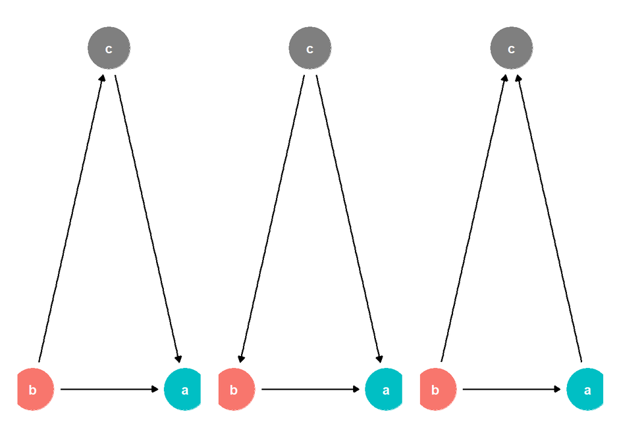

```r
dag.mediator <- dagify(
  a ~ b + c,
  c ~ b,
  exposure = "b", outcome = "a",
  coords = list(x = c(a = 1, b = 0, c = 0.5),
                y = c(a = 0, b = 0, c = 1.5))
)
viz.mediator <- ggdag_status(dag.mediator) + guides(fill = "none", color = "none") + theme_dag()

dag.fork <- dagify(
  a ~ b + c,
  b ~ c,
  exposure = "b", outcome = "a",
  coords = list(x = c(a = 1, b = 0, c = 0.5),
                y = c(a = 0, b = 0, c = 1.5))
)
viz.fork <- ggdag_status(dag.fork) + guides(fill = "none", color = "none") + theme_dag()

dag.collider <- dagify(
  a ~ b,
  c ~ a + b,
  exposure = "b", outcome = "a",
  coords = list(x = c(a = 1, b = 0, c = 0.5),
                y = c(a = 0, b = 0, c = 1.5))
)
viz.collider <- ggdag_status(dag.collider) + guides(fill = "none", color = "none") + theme_dag()

viz.mediator | viz.fork | viz.collider
```

## The Backdoor Adjustment Formula

We can systematically deconfound a causal effect by blocking every non-causal path without blockinf any causal path. We are looking for a set of variables Z that conform to the *backdoor criterion*:

> Given an ordered pair of variables (X,Y) in a model, a set of confounder variables Z satisfies the backdoor criterion if (1) no confounder variable Z is a descendent of X and (2) Z blocks every path between X and Y that contains an arrow into X.

When the causal model is a plausible representation of reality and the backdoor criterion is satisfied, then partial regression coefficients can be used as (causal) path coefficients (for linear relationships):[^1]

$$P(Y|do(X))=\sum_z P(Y|X,Z=z)P(Z=z)$$

We can visualize the application of the backdoor criterion to the three basic DAGs to understand its working. The `ggdag::ggdag_adjustment_set` function visualizes the necessary adjustment set according to the backdoor criterion.

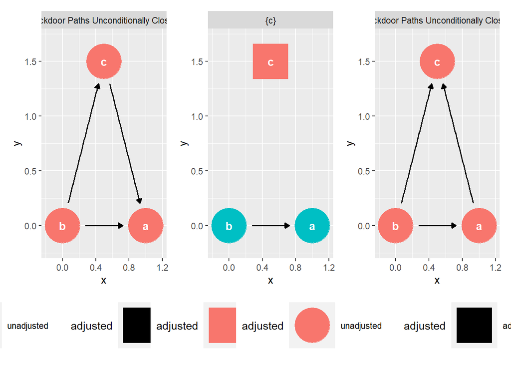

```r
adjust.mediator <- ggdag_adjustment_set(dag.mediator) +
  theme(legend.position="bottom")

adjust.fork <- ggdag_adjustment_set(dag.fork) +
  theme(legend.position="bottom")

adjust.collider <- ggdag_adjustment_set(dag.collider) +
  theme(legend.position="bottom")

adjust.mediator | adjust.fork | adjust.collider
```

Since the mediator and collider both do not contain a backdoor path (i.e., no arrow enters X), we do not need to adjust for anything. In other words: when estimating the causal effect of b on a, c must not be in the adjustment set because it is a descendant of b and, therefore, does not satisfy the first clause of the backdoor criterion. In the case of the fork, there is a backdoor path $b \leftarrow c \rightarrow a$. It needs to be adjusted for to estimate the effect of b on a. Correspondingly, we needed to control for variable c in the case of the fork.

## Examples

Let’s consider several examples DAGs to apply the backdoor adjustment to.

### Example 1

In this first example, Z acts as a fork on X and Y.

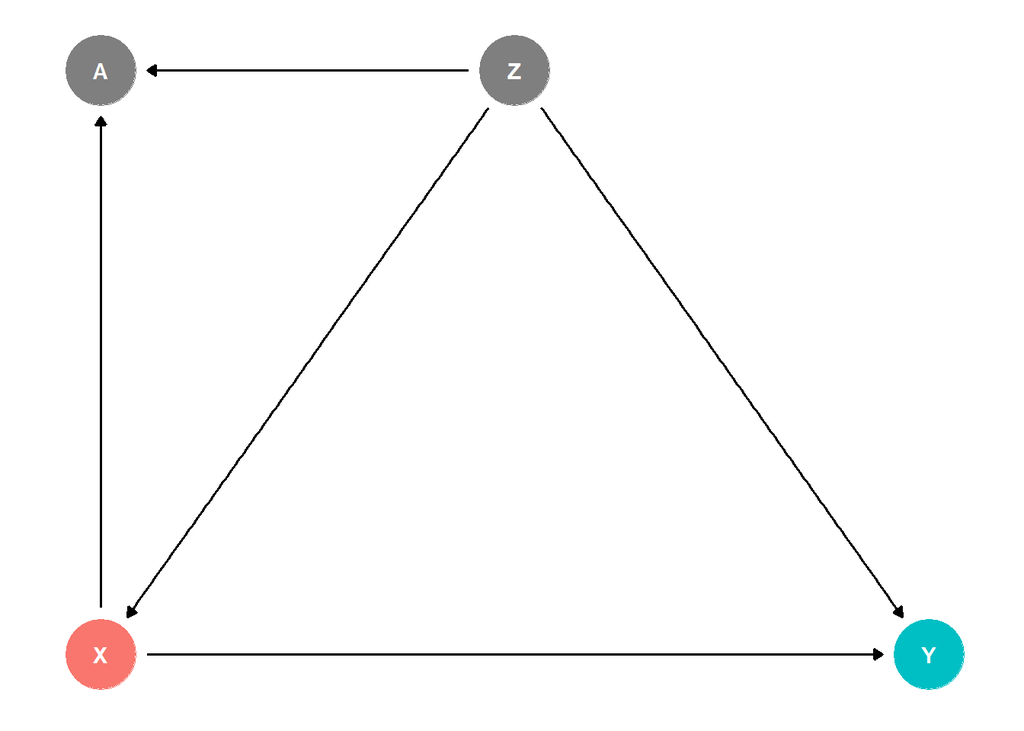

```r
dag.ex.1 <- dagify(
  Y ~ X + Z,
  X ~ Z,
  A ~ X + Z,

  exposure = "X", outcome = "Y",
  coords = list(x = c(X = 0, Y = 1, Z = 0.5, A = 0),
                y = c(X = 0, Y = 0, Z = 1, A = 1))
)
ggdag_status(dag.ex.1) +
  guides(fill = "none", color = "none") +
  theme_dag()
```

The path $X \leftarrow Z \rightarrow Y$ represents a non-blocked backdoor path, so we need to include Z in the adjustment set to block it.

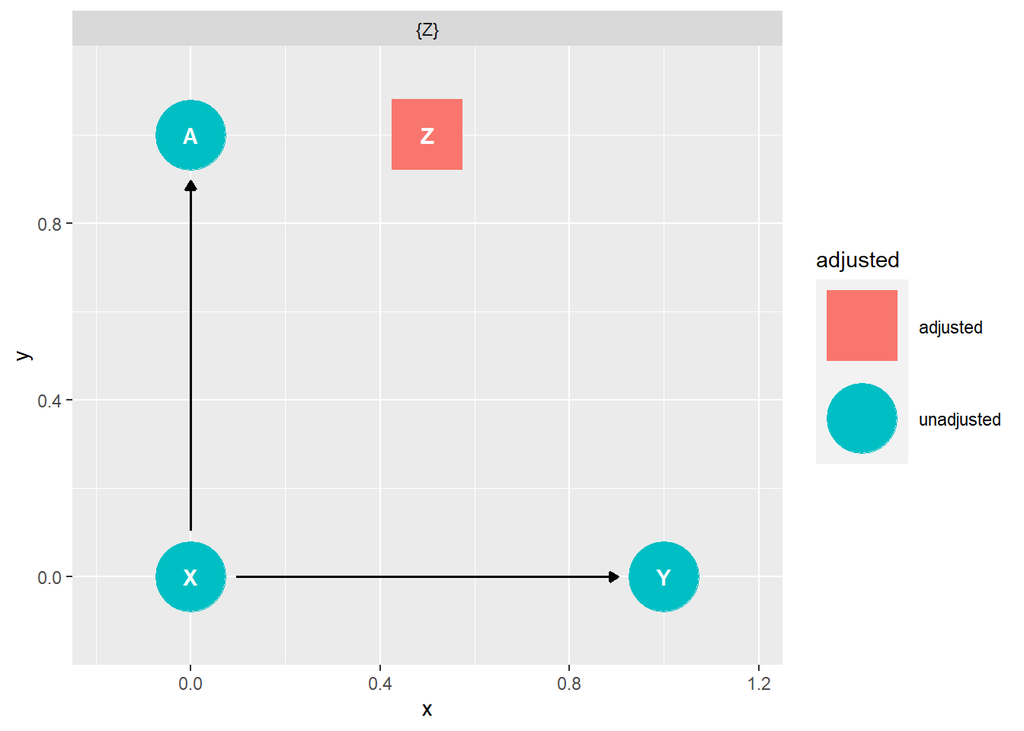

```r
ggdag_adjustment_set(dag.ex.1)
```

If Z is unobservable, one might be tempted to control for A instead. However, this opens the non-causal backdoor path $X \rightarrow A \leftarrow Z \rightarrow Y$.

### Example 2

A commponly discussed causal DAG is the following one, often referred to as an M-bias due to its shape.

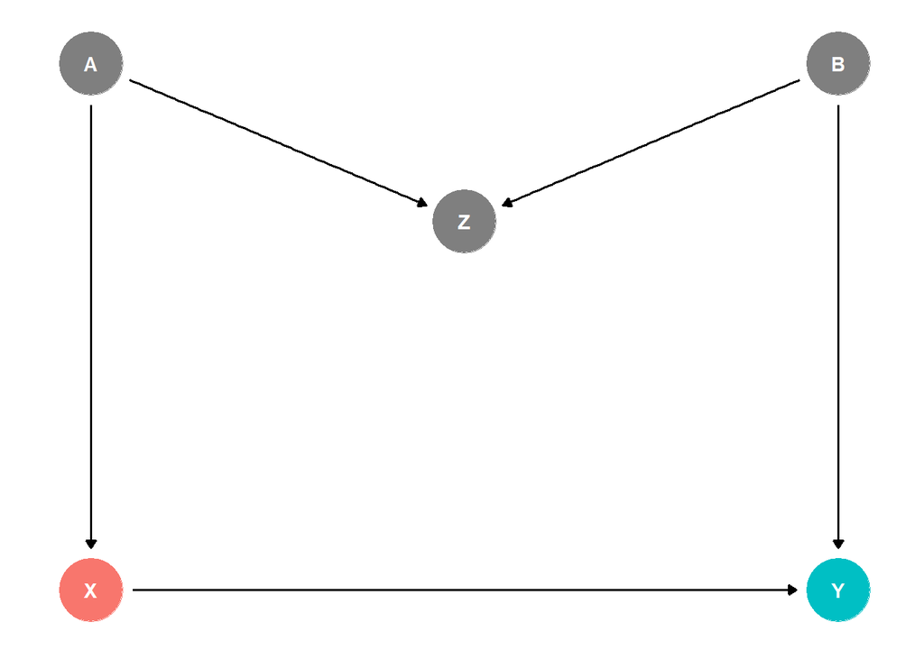

```r
dag.m.bias <- dagify(
  Y ~ X + B,
  X ~ A,
  Z ~ A + B,
  exposure = "X", outcome = "Y",
  coords = list(x = c(X = 0, Y = 1, Z = 0.5, A = 0, B = 1),
                y = c(X = 0, Y = 0, Z = 0.7, A = 1, B = 1))
)
ggdag_status(dag.m.bias) +
  guides(fill = "none", color = "none") +
  theme_dag()
```

There is only one non-causal backdoor path from X to Y, but it is not open beccause Z is a collider. Controlling for Z would open the path.

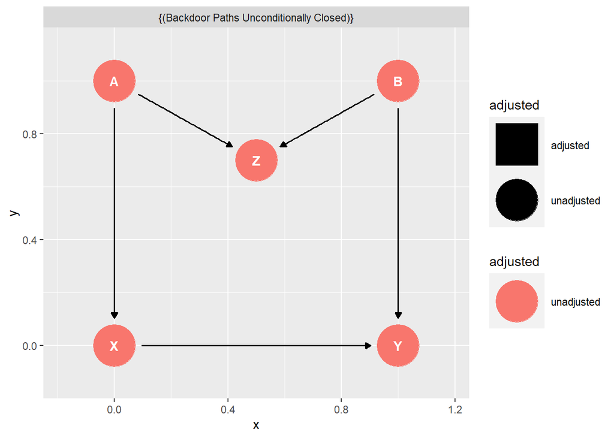

```r
ggdag_adjustment_set(dag.m.bias)
```

### Example 3

This DAG is a variant of the M-bias with one additional edge $Z \rightarrow X$.

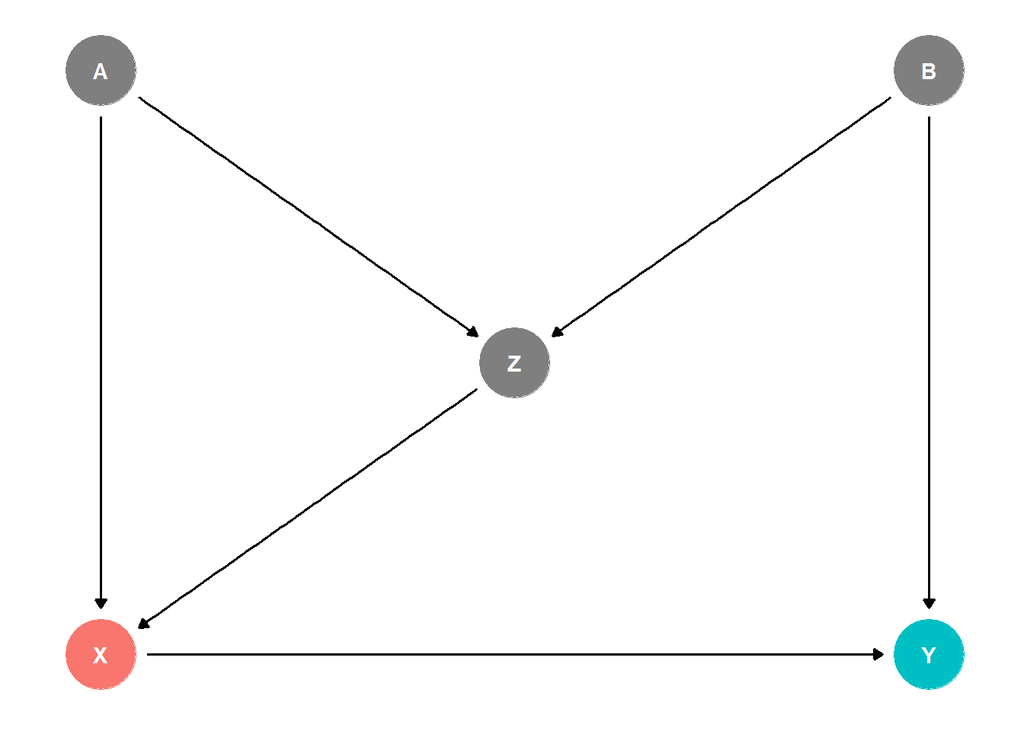

```r
dag.m.bias.2 <- dagify(
  Y ~ X + B,
  X ~ A + Z,
  Z ~ A + B,
  exposure = "X", outcome = "Y",
  coords = list(x = c(X = 0, Y = 1, Z = 0.5, A = 0, B = 1),
                y = c(X = 0, Y = 0, Z = 0.5, A = 1, B = 1))
)
ggdag_status(dag.m.bias.2) +
  guides(fill = "none", color = "none") +
  theme_dag()
```

Now, there are two backdoor paths:

1. $X \leftarrow Z \leftarrow B \rightarrow Y$, and
2. $X \leftarrow A \rightarrow Z \leftarrow B \rightarrow Y$

Backdoor path 2 is not open thanks to the collider Z but backdoor path 1 must be closed. To close it, we could control either B or A and Z. Controlling only for Z opens path 2, and controlling only for A does not close path 1.

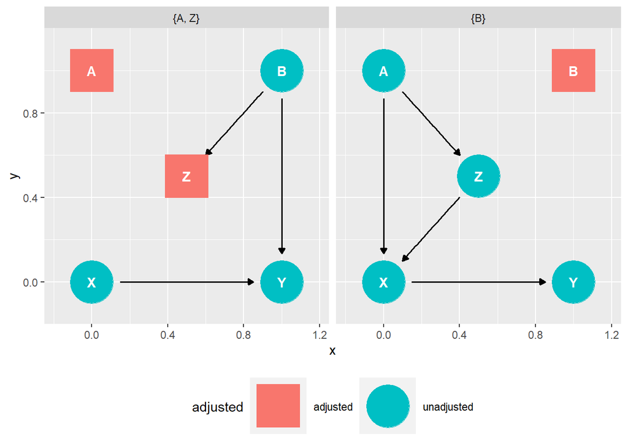

```r
ggdag_adjustment_set(dag.m.bias.2) +
  theme(legend.position="bottom")
```

[^1]: Pearl, J., & Mackenzie, D. (2018). The book of why: the new science of cause and effect. Basic books.